# Notes

# London bike data

Load in London bike data:

```r
london <- read_csv("LondonBikeData.csv")
dim(london)
```

```
## [1] 17414    10
```

```r
spec(london)
```

Convert season to character to match across datasets:

```r
london <- london %>%
  mutate(Season = ifelse(season == 0, "Spring",
                         ifelse(season == 1, "Summer",
                                ifelse(season == 2, "Autumn", "Winter"))))
```

Format timestamp as a Date object:

```r
london <- london %>%
  mutate(Date = as.Date(timestamp))
```

Extract hour from timestamp:

```r
london <- london %>%
  mutate(Hour = as.numeric(format(as.POSIXct(london$timestamp), format = "%H")))
```

Create rain or snow column:

```r
london <- london %>%
  mutate(Rain_or_snow = ifelse(weather_code %in% c(7, 10, 26), 1, 0))
table(london$Rain_or_snow)
```

```
##
##     0     1
## 15199  2215
```

Make max or min of temperature for each day

```r
temp = london %>% group_by(Date) %>% summarise(Min_T = min(t1), Max_T = max(t1))
london = inner_join(london, temp, by = "Date")
```

Make max or min of humidity for each day

```r
hum = london %>% group_by(Date) %>% summarise(Min_H = min(hum), Max_H = max(hum))
london= inner_join(london, hum, by = "Date")
```

Standardize variable names to match across datasets:

```r
london <- london %>%
  rename(Bike_count = cnt,
         Wind_speed = wind_speed,
         Is_weekend = is_weekend,
         Is_holiday = is_holiday,
         )
```

Keep only the columns that will be used as variables in our model:

```r
london <- london %>%
  select(Bike_count, Date, Hour, Min_T, Max_T, Min_H, Max_H, Wind_speed,
         Rain_or_snow, Is_weekend, Season, Is_holiday)
```

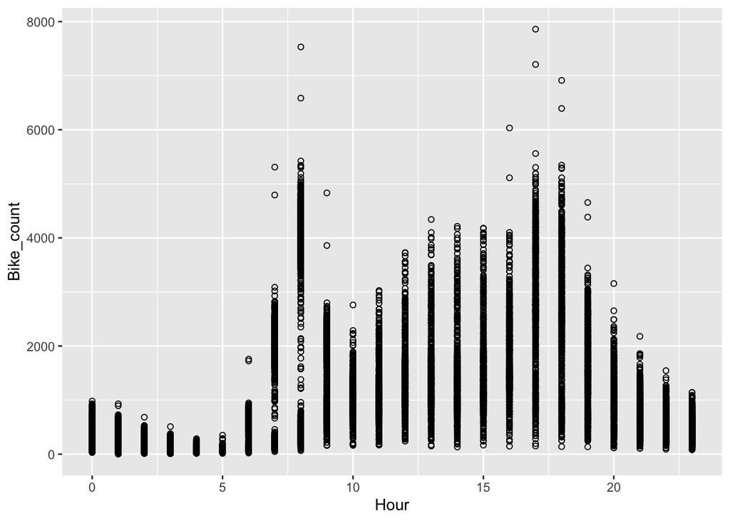

```r
ggplot(london, aes(x = Hour, y = Bike_count)) + geom_point(shape = 21)
```

# DC bike data

```r
dc <- read_csv("DCBikeData.csv")
dim(dc)
```

```
## [1] 17379    17
```

```r
spec(dc)
```

Convert season to character to match across datasets:

```r
dc <- dc %>%
  mutate(Season = ifelse(season == 1, "Spring",
                         ifelse(season == 2, "Summer",
                                ifelse(season == 3, "Autumn", "Winter"))))
```

Format date as a Date object:

```r
dc <- dc %>%
  mutate(Date = as.Date(dteday, format = "%Y-%m-%d"))
```

Create rain or snow column:

```r
dc <- dc %>%
  mutate(Rain_or_snow = ifelse(weathersit %in% c(3, 4), 1, 0))
table(dc$Rain_or_snow)
```

```
##
##     0     1
## 15957  1422
```

Create weekend column:

```r
dc <- dc %>%
  mutate(Is_weekend = ifelse(weekday %in% c(0,6), 1, 0))
```

Make max or min of temperature for each day

```r
temp = dc %>% group_by(Date) %>% summarise(Min_T = min(temp), Max_T = max(temp))
dc = inner_join(dc, temp, by = "Date")
```

Make max or min of humidity for each day

```r
hum = dc %>% group_by(Date) %>% summarise(Min_H = min(hum), Max_H = max(hum))
dc = inner_join(dc, hum, by = "Date")
```

Standardize variable names to match across datasets:

```r
dc <- dc %>%
  rename(Bike_count = cnt,
         Wind_speed = windspeed,
         Is_holiday = holiday,
         Hour = hr)
```

Keep only the columns that will be used as variables in our model:

```r
dc <- dc %>%
  select(Bike_count, Date, Hour, Min_T, Max_T, Min_H, Max_H, Wind_speed,
         Rain_or_snow, Is_weekend, Season, Is_holiday)
```

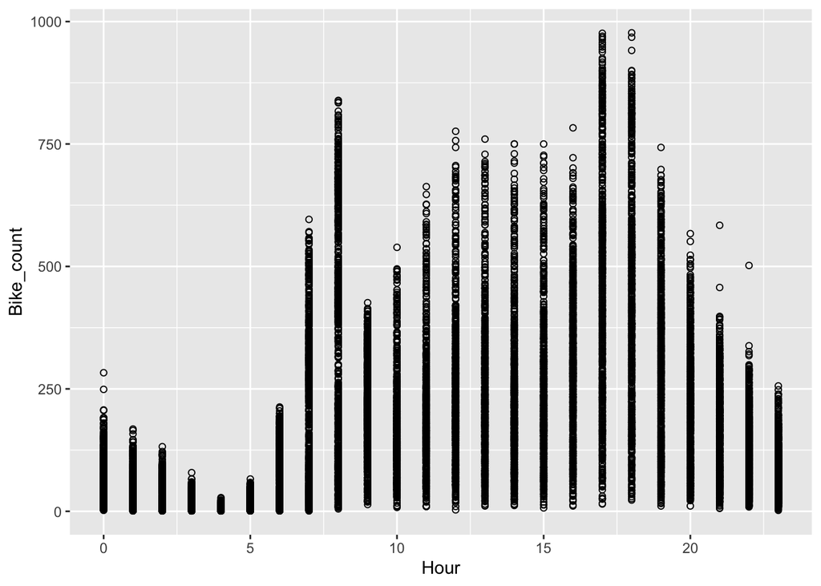

```r
ggplot(dc, aes(x = Hour, y = Bike_count)) + geom_point(shape = 21)
```